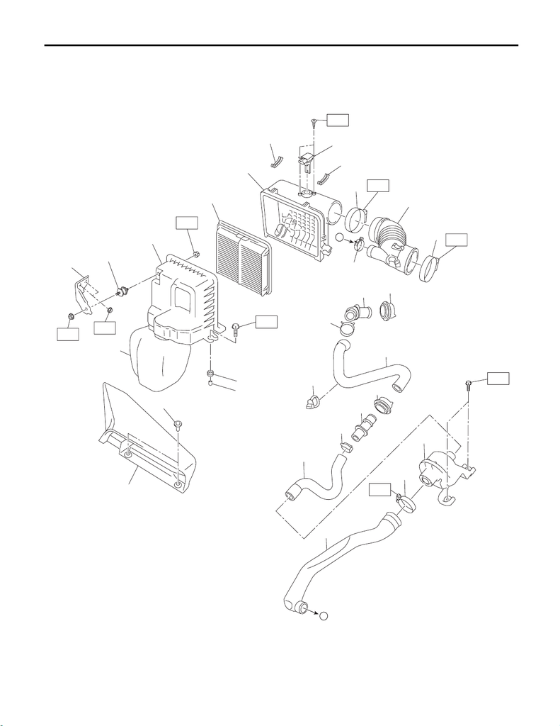

IN(STI)-2

General Description

INTAKE (INDUCTION)

1. General Description

A: COMPONENT

1. AIR CLEANER

IN-03637

(6)

(7)

(4)

(3)

(3)

(2)

(1)

(5)

(5)

(18)

(19)

(19)

(23)

(21)

(22)

(21)

(20)

(24)

(25)

(15)

(16)

(17)

(11)

(12)

(14)

(10)

(13)

(8)

(9)

T4

T4

T4

T2

T3

T2

T2

T3

T1

A

A

[figure not shown]

IN(STI)-3

General Description

INTAKE (INDUCTION)

(1) Mass air flow and intake air tem-

perature sensor

(12) Cushion (22) Hose (rear)

(2) Air cleaner case (rear) (13) Resonator chamber (23) Connector

(3) Clip (14) Air cleaner case bracket (24) Hose clip

(4) Air intake boot (15) Chamber duct (25) Clip

(5) Clamp (16) Clamp

(6) Air cleaner element (17) Chamber ASSY Tightening torque: N·m (kgf-m, ft-lb)

(7) Air cleaner case (front) (18) Hose (front) T1: 1 (0.1, 0.7)

(8) Air intake duct (19) Clip T2: 2.5 (0.3, 1.8)

(9) Clip (20) Connector T3: 6 (0.6, 4.4)

(10) Cushion (21) Grommet T4: 7.5 (0.8, 5.5)

(11) Spacer

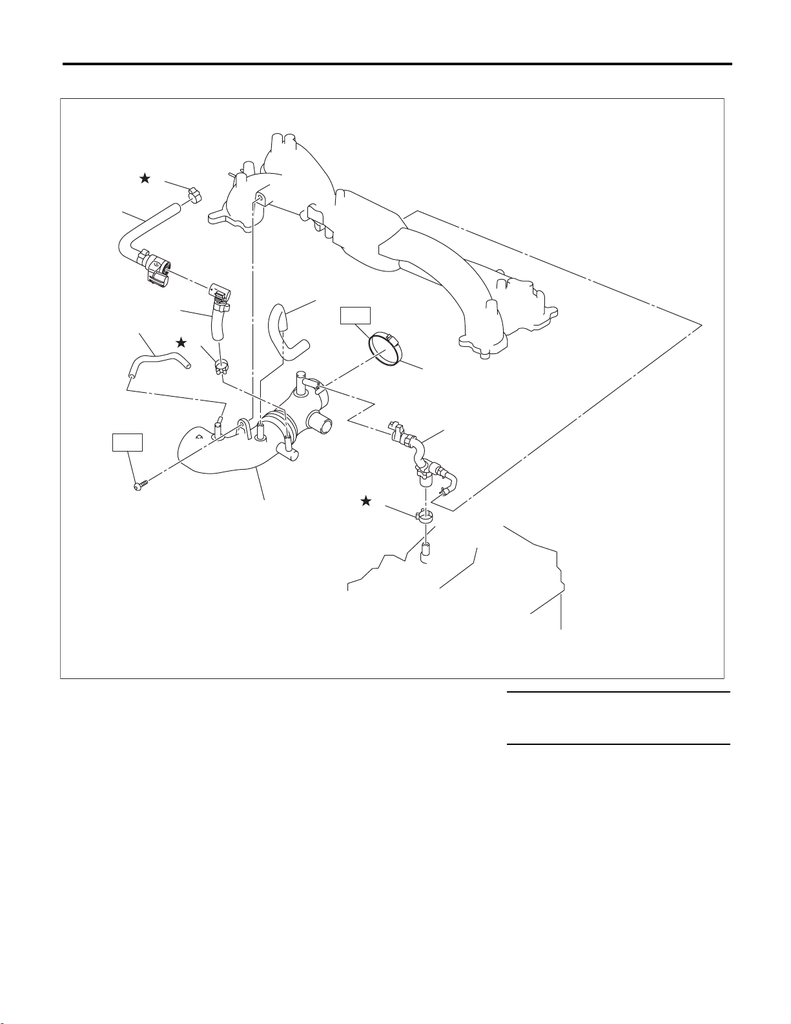

IN(STI)-4

General Description

INTAKE (INDUCTION)

2. INTAKE DUCT

(1) Clamp (6) Vacuum hose A Tightening torque: N·m (kgf-m, ft-lb)

(2) PCV hose ASSY A (7) Intake duct T1: 3 (0.3, 2.2)

(3) Clip (8) Clamp T2: 17 (1.7, 12.5)

(4) PCV hose ASSY B (9) Vacuum hose B

(5) PCV hose ASSY C

IN-03581

(1)

(7)

(9)

(6)

T2

T1

(2)

(8)

(5)

(3)

(4)

(3)

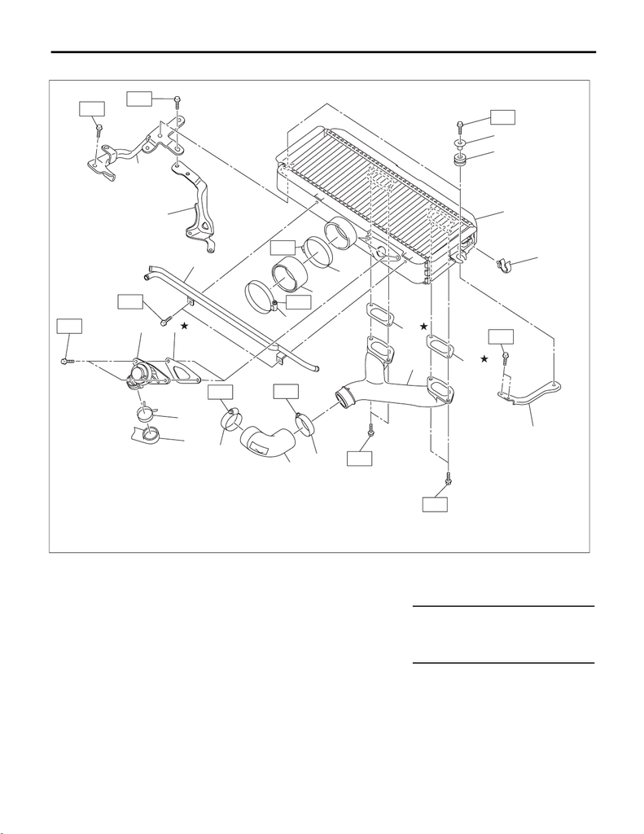

IN(STI)-5

General Description

INTAKE (INDUCTION)

3. INTERCOOLER

(1) Intercooler (9) Gasket (17) Intake duct

(2) Intercooler stay RH No. 1 (10) Clip (18) Clip

(3) Intercooler stay RH No. 2 (11) Air by-pass hose

(4) Intercooler stay LH (12) Spacer Tightening torque: N·m (kgf-m, ft-lb)

(5) Clamp (13) Cushion T1: 3 (0.3, 2.2)

(6) Air duct hose (14) Gasket T2: 5.5 (0.6, 4.1)

(7) PCV pipe (15) Intercooler duct T3: 16 (1.6, 11.8)

(8) Air by-pass valve (16) Clamp

T3

T3

T3

(3)

(5)

(6)

(5)

(8)

(9)

(10)

(11)

(1)

(4)

(18)

IN-03558

(14)

(14)

T3

T2

(7)

T3

(13)

(12)

(2)

T1

T1

(16)

T1

T1

(16)

(17)

(15)

T3

T3

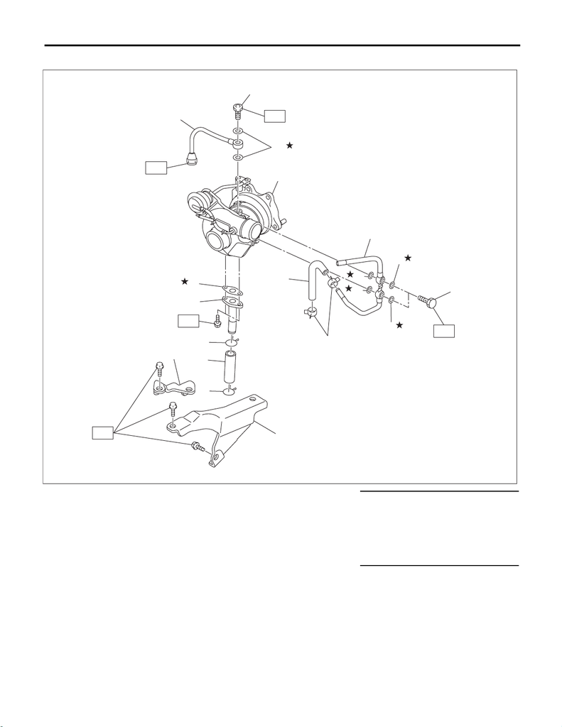

IN(STI)-6

General Description

INTAKE (INDUCTION)

4. TURBOCHARGER

(1) Oil inlet pipe (9) Clip Tightening torque: N·m (kgf-m, ft-lb)

(2) Gasket (10) Oil outlet hose T1: 4.9 (0.5, 3.6)

(3) Turbocharger (11) Turbocharger stay RH T2: 16 (1.6, 11.8)

(4) Water pipe (12) Turbocharger stay LH T3: 20 (2.0, 14.8)

(5) Clip (13) Gasket T4: 23 (2.3, 17.0)

(6) Engine coolant hose (14) Union bolt A T5: 33 (3.4, 24.3)

(7) Gasket (15) Union bolt B

(8) Oil outlet pipe

IN-02946

T2

T3

(1)

(13)

(3)

(12)

(11)

T5

T1

(8)

(9)

(7)

(10)

(9)

(14)

(5)

T4

(4)

(6)

(2)

(2)

(2)

(2)

(15)

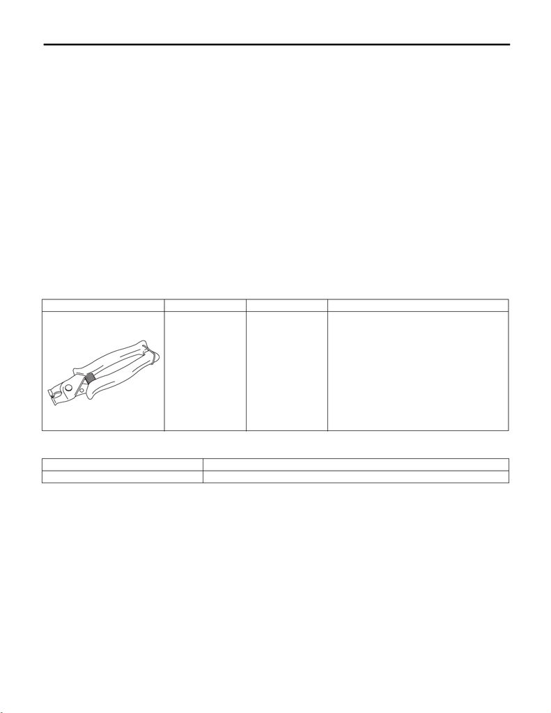

IN(STI)-7

General Description

INTAKE (INDUCTION)

B: CAUTION

• Prior to starting work, pay special attention to the following:

1. Always wear work clothes, a work cap, and protective shoes. Additionally, wear a helmet, protective

goggles, etc. if necessary.

2. Protect the vehicle using a seat cover, fender cover, etc.

3. Prepare the service tools, clean cloth, containers to catch grease and oil, etc.

• Vehicle components are extremely hot immediately after driving. Be wary of receiving burns from heated

parts.

• When performing a repair, identify the cause of trouble and avoid unnecessary removal, disassembly and

replacement.

• Before disconnecting connectors of sensors or units, be sure to disconnect the ground cable from battery.

• Always use the jack-up point when the shop jacks or rigid racks are used to support the vehicle.

• Remove contamination including dirt and corrosion before removal, installation, disassembly or assembly.

• Keep the removed parts in order and protect them from dust and dirt.

• All removed parts, if to be reused, should be reinstalled in the original positions with attention to the correct

directions, etc.

• Bolts, nuts and washers should be replaced with new parts as required.

• Be sure to tighten the fasteners including bolts and nuts to the specified torque.

C: PREPARATION TOOL

1. SPECIAL TOOL

2. GENERAL TOOL

ILLUSTRATION TOOL NUMBER DESCRIPTION REMARKS

18353AA000 CLAMP PLIERS • Used for removing and installing the PCV hose

assembly.

• This tool is made by the French company

CAILLAU. (code) 54.0.000.205

To make it easier to obtain, it has been provided

with a tool number.

TOOL NAME REMARKS

Mighty Vac Used for checking waste gate actuator and air by-pass valve.

ST18353AA000